# Homework 2: The Big Short

**This homework is due Friday February 26, 2016 at 5:00 PM. When complete, submit your code in the R Markdown file and the knitted HTML via GitHub.**

# Background

This homework is motivated by circumstances surrounding the [financial crisis of 2007-2008](https://en.wikipedia.org/wiki/Financial_crisis_of_2007%E2%80%9308). We titled the homework *The Big Short*, after the book on the same topic that was also recently made into a movie.

Part of what caused the financial crisis was that the risk of certain securities sold by financial institutions were underestimated. Specifically, the risk of mortgage-backed securities (MBS) and collateralized debt obligations (CDO), the price of which depends on homeowners making their monthly payments, was grossly underestimated. A combination of factors resulted in many more defaults than were expected. This resulted in a crash of the prices of these securities. As a consequence, banks lost so much money that they needed bailouts to avoid default.

Here we present a **very** simplified version of what happened with some of these securities. Hopefully it will help you understand how a wrong assumption about the statistical behavior of events can lead to substantial differences between what the model predicts and what actually happens. Specifically, we will see how using an independence assumption can result in misleading conclusions. Before we start with the specific application we ask you about a simple casino game.

# Problem 1

In the game of [roullete](https://en.wikipedia.org/wiki/Roulette) you can bet on several things including black or red. On this bet, if you win, you double your earnings. How does the casino make money on this then? If you look at the [possibilities](http://www.math.uah.edu/stat/games/Roulette.png) you realize that the chance of red or black are both slightly less than 1/2. There are two green spots, so the of landing on black (or red) is actually 18/38, or 9/19.

## Problem 1A

Let’s make a quick sampling model for this simple version of roulette. You are going to bet a dollar each time you play and always bet on black. Make a box model for this process using the `sample` function. Write a function `get_outcome` that takes as an argument the number of times you play $N$ and returns your earnings $S_N$.

```r
roullete <- rep( c("red", "black", "green"), times = c(18,18,2))
get_outcome <- function(N) {
        bet <- sample(roullete, N, replace=T)
        sum(bet=="black")
}
```

## Problem 1B

Use Monte Carlo simulation to study the distribution of total earnings $S_N$ for $N=10,25,100,1000$. That is, study the distribution of earnings for different number of plays. What are the distributions of these two random variables? How do the expected values and standard errors change with $N$? Then do the same thing for the average winnings $S_N/N$. What result that you learned in class predicts this?

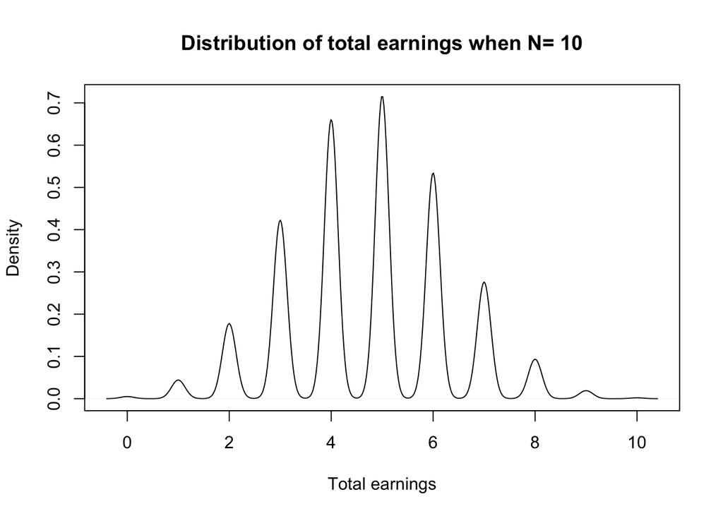

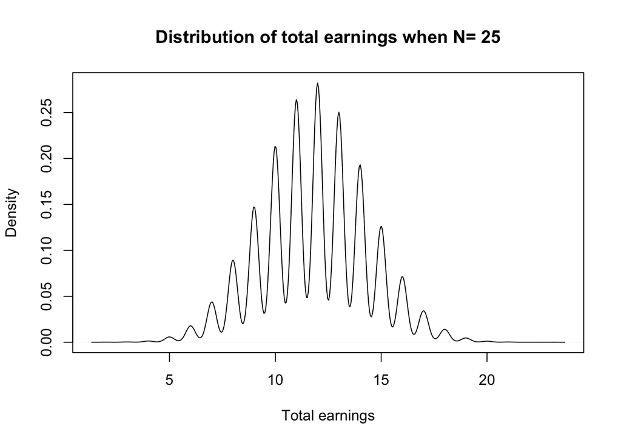

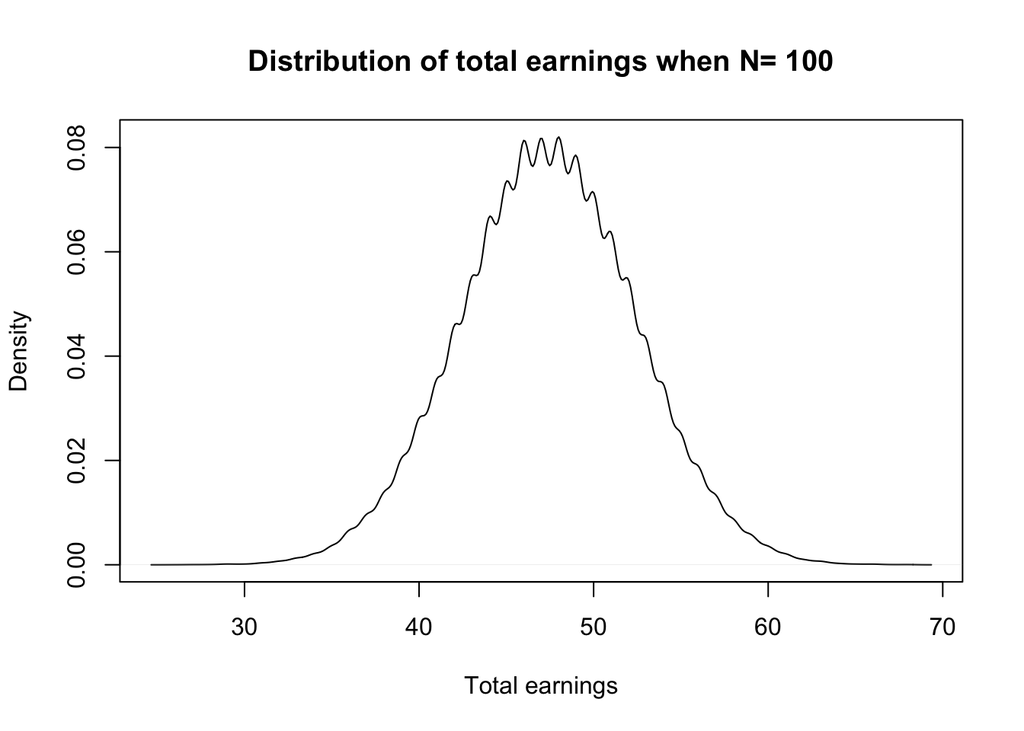

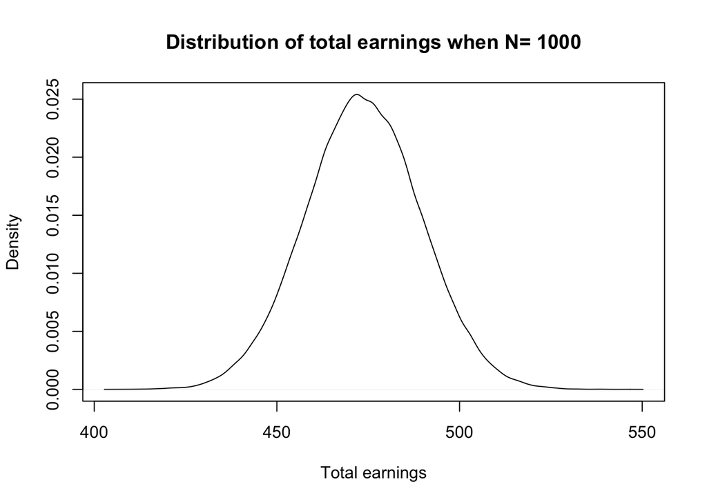

```r
N <- c(10,25,100,1000)

# Distribution of total earnings
simulation1 <- function(N, B = 10^5){
        earnings <- replicate(B, get_outcome(N))
        plot(density(earnings), xlab="Total earnings",
             main=paste("Distribution of total earnings when N=",N))
        c(N, mean(earnings), sd(earnings))
}

summary1 <- as.data.frame(sapply(N, simulation1))
```

```r
rownames(summary1) <- c("N","Mean","Standard error")
summary1[1,] <- format(summary1[1,],digits=2)
summary1
```

```
##                              V1               V2               V3
## N                            10               25              100
## Mean                    4.73284          11.8457         47.39617
## Standard error 1.58380258198621 2.49671260775814 4.99133333541096
##                              V4
## N                          1000
## Mean                   473.6579
## Standard error 15.7567188948684
```

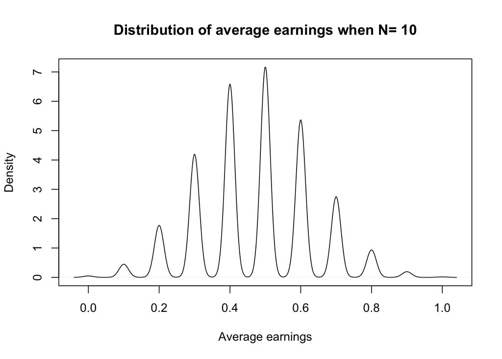

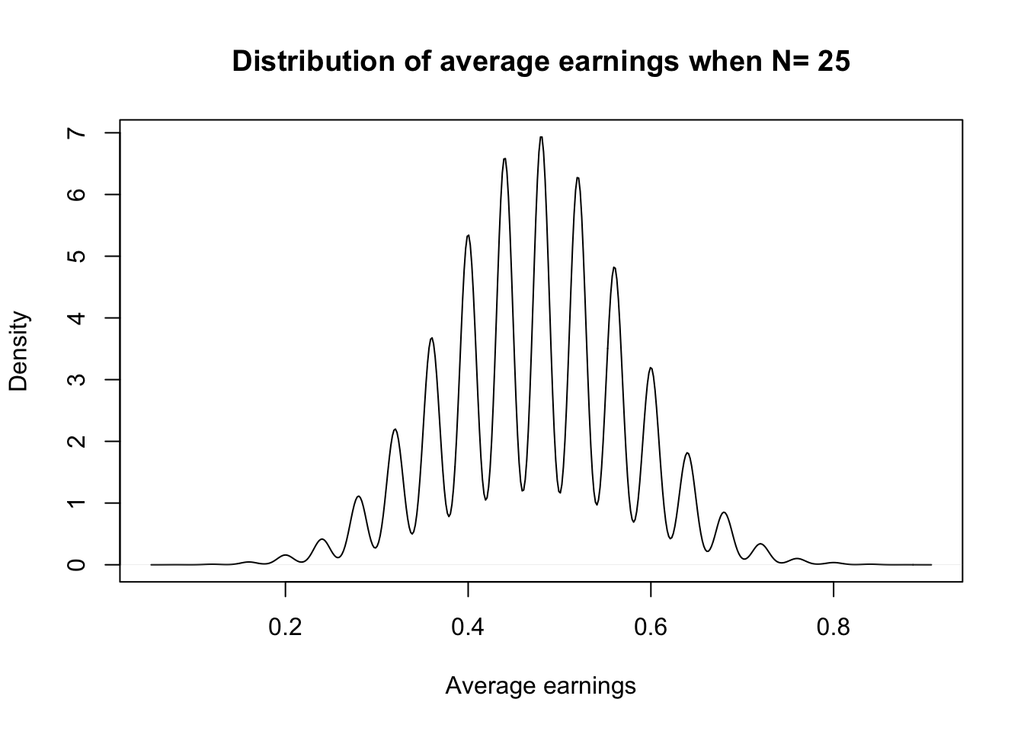

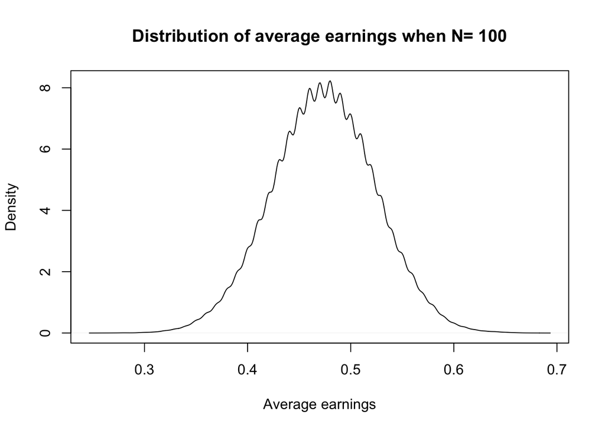

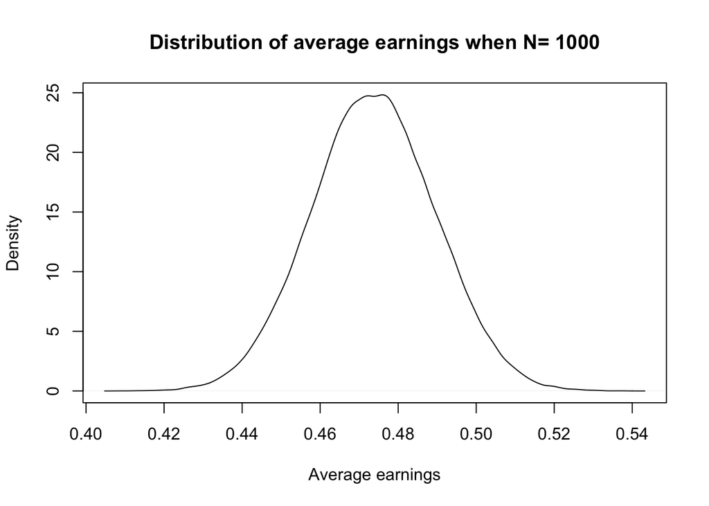

```r
# Distribution of total earnings
simulation2 <- function(N, B = 10^5){
        earnings.average <- replicate(B, get_outcome(N))/N
        plot(density(earnings.average), xlab="Average earnings",
             main=paste("Distribution of average earnings when N=",N))
        c(N, mean(earnings.average), sd(earnings.average))
}

summary2 <- as.data.frame(sapply(N, simulation2))
```

```r
rownames(summary2) <- c("N","Mean","Standard error")
summary2[1,] <- format(summary2[1,],digits=2)
summary2
```

```
##                              V1                 V2                 V3
## N                            10                 25                100
## Mean                   0.473541          0.4740296          0.4739261
## Standard error 0.15840224819024 0.0999075079207833 0.0499693676982917
##                                V4
## N                            1000
## Mean                   0.47365474
## Standard error 0.0158211200175836
```

All the distributions for total earnings are approximately symmetrical, with high density in the middle and decreased density on two ends. Since total earnings can only take on values no larger than N, when N is not large enough (N = 10, 25, 100), the plot appears to fluctuate a bit. When N increases to 1000, the curve appears smooth, and we can see clearly that it is approximately normally distributed.

Both the expected values for total earnings and their corresponding standard errors increase as N increases. The expected values are all a bit smaller than N/2.

The distributions for average earnings have similar shape with the ones for total earnings. We still see a approximate normal distribution. What is different for average earnings is that the X axis can be comparable across different plots with different Ns.

The expected values for average earnings are close (0.474) for different Ns. The standard error decreases as N increases.

What result that you learned in class predicts this? The total earning follows binomial distribution, with n=N, p = 18/38 = 9/19.